# GLM para dados contínuos

Gabriela Neres, Mariane Melo, Pedro Lopes

## 1 Introdução

A diversidade beta representa a variação na composição de espécies entre diferentes locais, refletindo como as comunidades mudam ao longo de gradientes ambientais, espaciais ou temporais. Com base nesse conceito, Legendre & Cáceres (2013) propuseram o LCBD (Local Contribution to Beta Diversity), que mede a singularidade ecológica de uma comunidade dentro de uma metacomunidade, o quanto aquela comunidade “contribui” para a diversidade beta. Valores altos de LCBD indicam locais com espécies raras, composições únicas ou baixa riqueza, destacando comunidades importantes para a manutenção da diversidade regional e úteis para definir áreas prioritárias de conservação e restauração.

Os dados utilizados nesta análise são valores de LCBD de comunidades em algumas metacomunidades de rios. As comunidades podem ser de trechos intermitentes (que podem secar) ou perenes (que não secam) destes rios.

Este script tem como objetivo ajustar modelos lineares generalizados (GLM) para o índice **LCBD total** (Local Contribution to Beta Diversity) para testar se fatores como **tipo de rio (perene ou intermitente)**, **ordem do rio** e **metacomunidade** são variáveis que descrevem os valores de LCBD.  
O objetivo é comparar modelos para dados contínuos (Gamma e Log-normal), verificar a adequação dos modelos e visualizar os resultados.

## 2 Carregando pacotes utilizados

```r
library(dplyr)       # Manipulação de dados
library(ggplot2)     # Visualização de dados
library(glmmTMB)     # Modelos GLM
library(performance) # Diagnóstico de modelos
library(DHARMa)      # Resíduos simulados para GLM
library(ggeffects)   # Predições e gráficos de efeitos
```

## 3 Carregando os dados

Leitura do arquivo CSV para obtenção do dataset.

```r
dados <- read.csv(paste0(path, "/output/processed_data/dados_modelos.csv"))

# Estrutura do dataframe
str(dados)
```

```
## 'data.frame':    449 obs. of  18 variables:
##  $ cd_site                  : int  6000890 6000950 6000980 6000990 6000993 6000997 6000998 6001000 6001180 6001190 ...
##  $ metacomm_id              : chr  "U012" "U012" "U012" "U012" ...
##  $ meta_lvl                 : chr  "U0" "U0" "U0" "U0" ...
##  $ year                     : int  2014 2014 2014 2014 2014 2014 2014 2014 2014 2014 ...
##  $ richness                 : int  51 48 52 52 45 49 38 60 45 53 ...
##  $ lcbd_total               : num  0.0139 0.0108 0.0117 0.0104 0.0144 ...
##  $ lcbd_rep                 : num  0.021 0.0114 0.01 0.0151 0.0236 ...
##  $ lcbd_rich                : num  0.00556 0.0092 0.01353 0.0024 0.00339 ...
##  $ type                     : chr  "per" "per" "per" "per" ...
##  $ rang_corr                : int  3 3 3 2 4 3 4 5 3 4 ...
##  $ attr_inter               : num  -0.982 -0.852 -0.783 -0.644 -1.138 ...
##  $ latitude                 : num  1.84 1.92 1.9 1.95 1.84 ...
##  $ longitude                : num  0.241 0.504 0.268 0.39 0.28 ...
##  $ PCT_EXTENSIVE_AGRICULTURE: num  2.342 0.667 2.402 0.61 1.921 ...
##  $ PCT_INTENSIVE_AGRICULTURE: num  -0.36 0.453 -0.422 -0.941 -0.281 ...
##  $ PCT_URBAN                : num  -0.3347 -0.0817 -0.2229 -0.5147 -0.3644 ...
##  $ PCT_NEAR_NATURAL         : num  -0.66 -0.605 -0.675 0.591 -0.523 ...
##  $ RIPAR30M_R               : num  -0.5673 0.0265 -0.7678 1.2244 -0.3499 ...
```

## 4 Ajuste das variáveis

Transformamos colunas categóricas em fatores.

```r
dados[, c("metacomm_id", "cd_site", "meta_lvl", "type")] <-
  lapply(dados[, c("metacomm_id", "cd_site", "meta_lvl", "type")], factor)
```

## 5 Exploração inicial dos dados

Visualizamos a distribuição do LCBD e sua variação com as variáveis que pretendemos investigar.

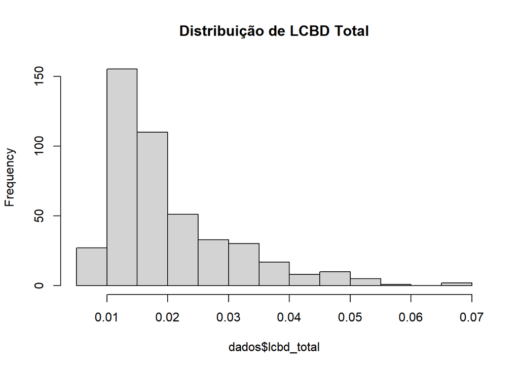

```r
hist(dados$lcbd_total, main = "Distribuição de LCBD Total")
```

```r
summary(dados$lcbd_total)
```

```
##     Min.  1st Qu.   Median     Mean  3rd Qu.     Max.
## 0.007713 0.012832 0.016436 0.020045 0.023994 0.066625
```

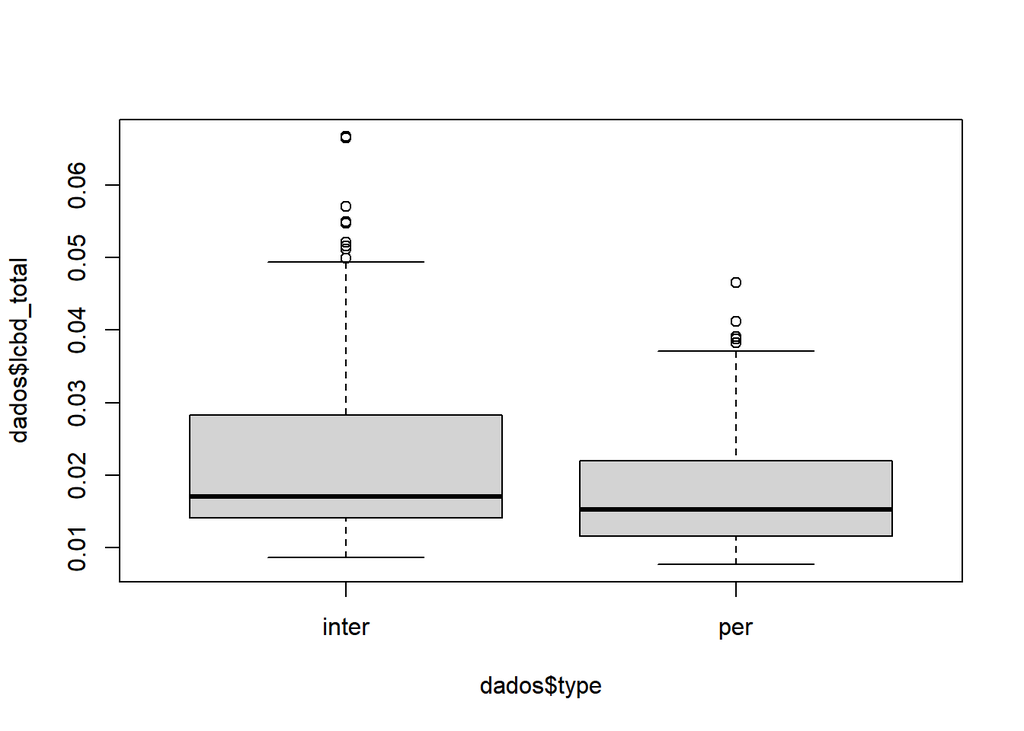

```r
plot(dados$lcbd_total ~ dados$type) #Rio perene vs. intermitente
```

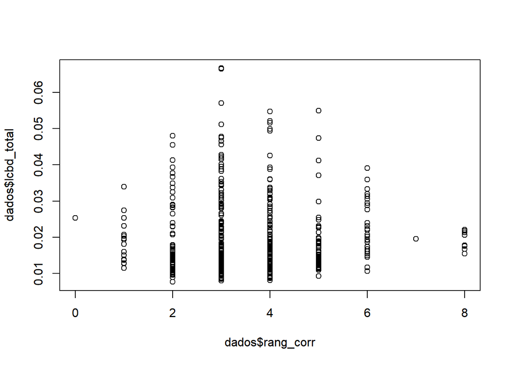

```r
plot(dados$lcbd_total ~ dados$rang_corr) #Ordem do rio
```

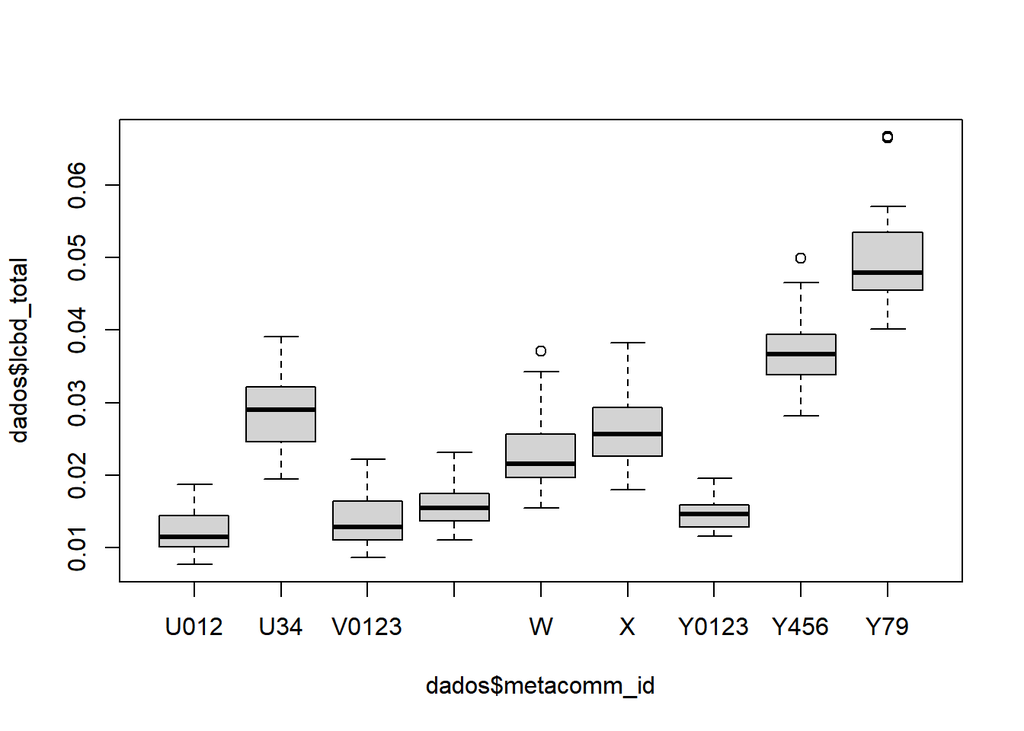

```r
plot(dados$lcbd_total ~ dados$metacomm_id) #metacomunidades
```

Nesta primeira visualização, o tipo e a ordem do rio não parecem ter muita relação com o LCBD. Porém é possível visualizar diferenças de valores de LCBD entre as metacomunidades. Agora, vamos modelar esses dados.

## 6 Ajuste dos modelos GLM

Ajustamos dois modelos:

- **Distribuição Gamma** com link log
- **Distribuição Log-normal** com link log

Estes modelos nos informarão qual distribuição descreve melhor os valores de LCBD.

```r
model_gamma <- glmmTMB(
  lcbd_total ~ type + rang_corr + metacomm_id,
  data = dados,
  family = Gamma("log")
)

model_log <- glmmTMB(
  lcbd_total ~ type + rang_corr + metacomm_id,
  data = dados,
  family = lognormal("log")
)
```

## 7 Comparação e diagnóstico dos modelos

Comparamos os modelos pelo **AIC** (Critério de Informação de Akaike): menor AIC indica melhor ajuste.

```r
AIC(model_log, model_gamma)
```

```
##             df       AIC
## model_log   12 -3751.197
## model_gamma 12 -3807.667
```

Observamos que o modelo Gamma apresentou menor AIC, logo tem potencial de ser o modelo escolhido. Vamos avaliar outros aspectos…

Em seguida, vamos visualizar a relação dos dados observados com os preditos pelos modelos

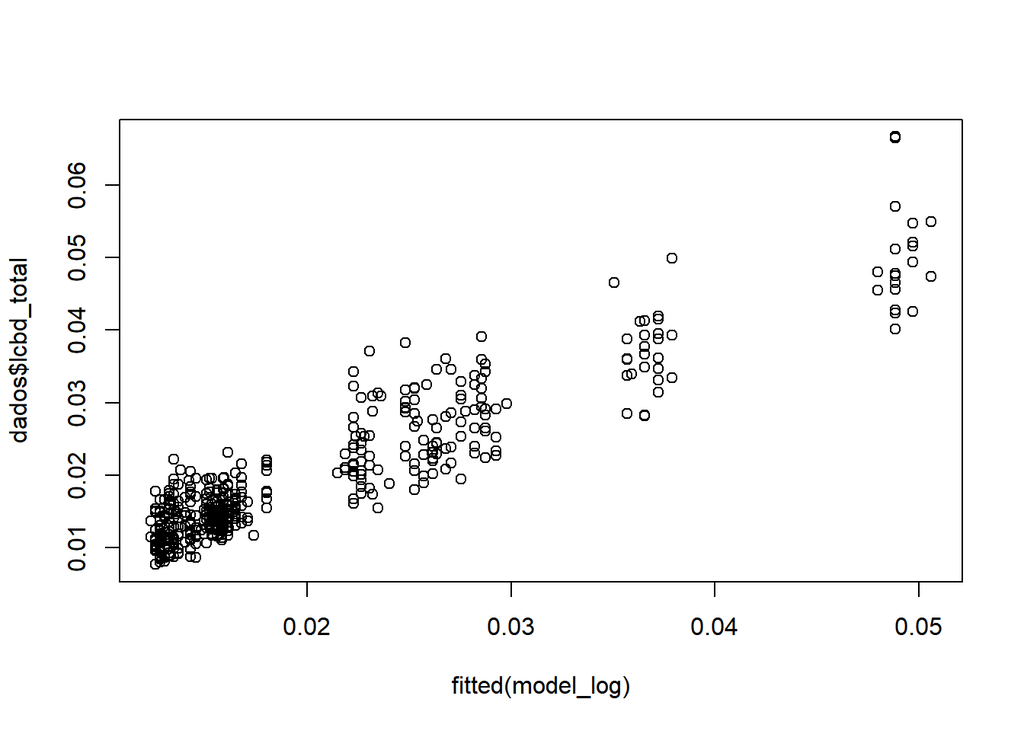

```r
plot(dados$lcbd_total ~ fitted(model_log))
```

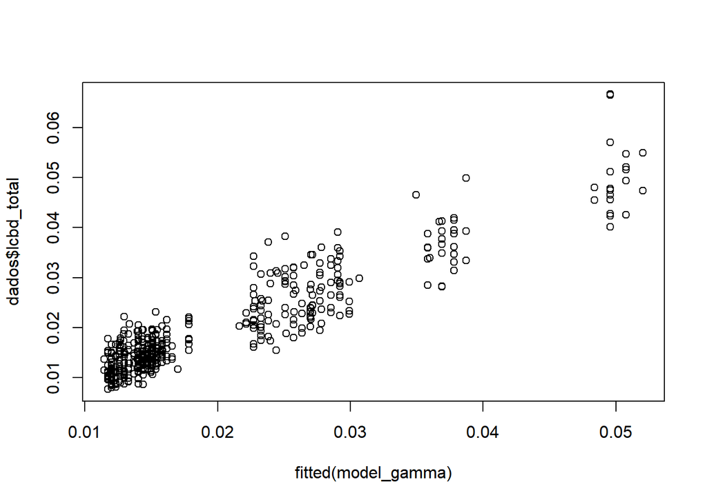

```r
plot(dados$lcbd_total ~ fitted(model_gamma))
```

Não parece haver tanta diferença.

Agora utilizamos a função `simulateResiduals()` do pacote **DHARMa** para verificar resíduos simulados e a função `check_model()` do pacote **performance** para checar suposições gerais dos modelos.

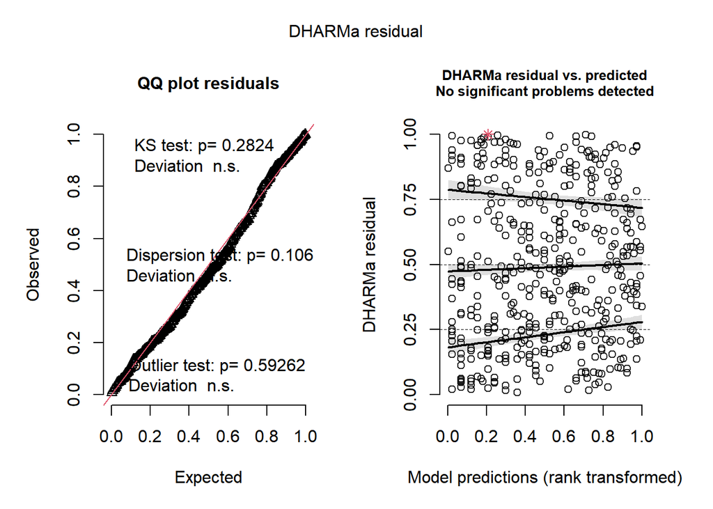

```r
resG <- simulateResiduals(model_gamma, n = 1000, plot = TRUE) #Modelo Gamma
```

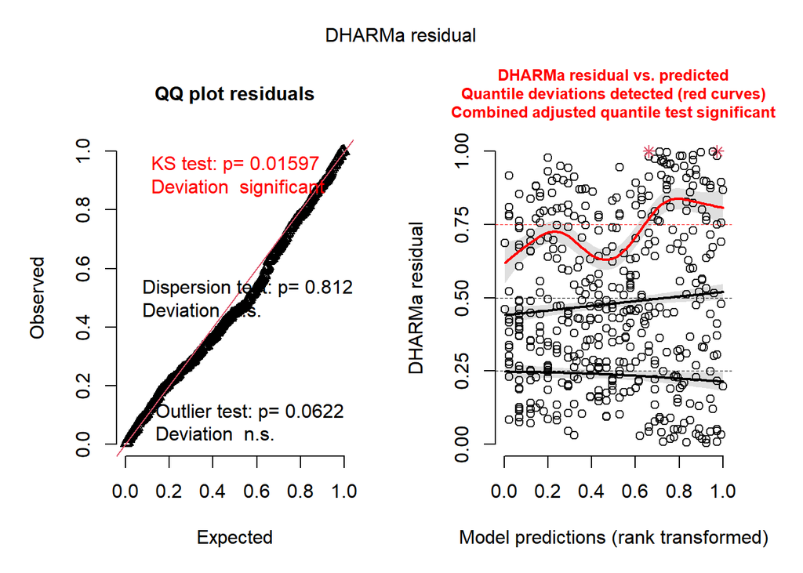

```r
resLN <- simulateResiduals(model_log, n = 1000, plot = TRUE) #Modelo lognormal
```

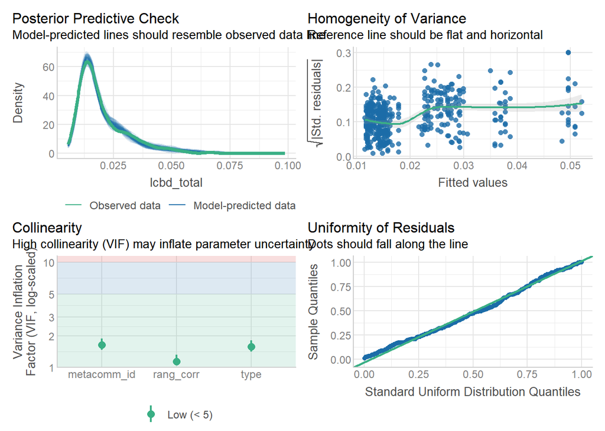

```r
check_model(model_gamma) #Modelo Gamma
```

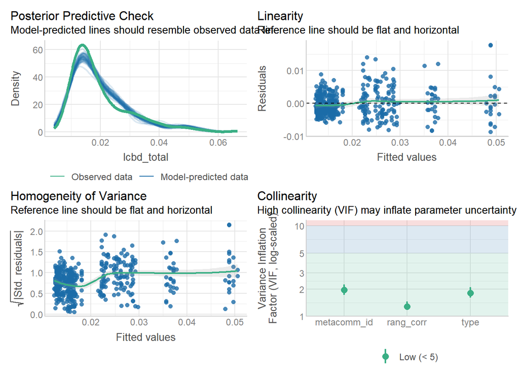

```r
check_model(model_log) #Modelo lognormal
```

De modo geral, é perceptível que o modelo gamma apresentou um melhor ajuste aos dados, com resíduos mais uniformes e com melhores predições.

Vamos avaliar as relações das variáveis:

```r
summary(model_gamma)
```

```
##  Family: Gamma  ( log )
## Formula:          lcbd_total ~ type + rang_corr + metacomm_id
## Data: dados
##
##       AIC       BIC    logLik -2*log(L)  df.resid
##   -3807.7   -3758.4    1915.8   -3831.7       437
##
##
## Dispersion estimate for Gamma family (sigma^2): 0.0352
##
## Conditional model:
##                  Estimate Std. Error z value Pr(>|z|)
## (Intercept)      -4.41587    0.03477 -127.01  < 2e-16 ***
## typeper          -0.07811    0.02220   -3.52 0.000435 ***
## rang_corr         0.02421    0.00693    3.49 0.000476 ***
## metacomm_idU34    0.81024    0.03925   20.64  < 2e-16 ***
## metacomm_idV0123  0.07666    0.03212    2.39 0.017012 *
## metacomm_idV4567  0.19531    0.03501    5.58 2.42e-08 ***
## metacomm_idW      0.63609    0.03542   17.96  < 2e-16 ***
## metacomm_idX      0.73670    0.03754   19.63  < 2e-16 ***
## metacomm_idY0123  0.12617    0.03527    3.58 0.000347 ***
## metacomm_idY456   1.06754    0.04413   24.19  < 2e-16 ***
## metacomm_idY79    1.33893    0.05125   26.13  < 2e-16 ***
## ---
## Signif. codes:  0 '***' 0.001 '**' 0.01 '*' 0.05 '.' 0.1 ' ' 1
```

Todas parecem ter um efeito significativo para explicar o LCBD Total.

## 8 Visualização dos efeitos ajustados

Plotamos as predições com a função `ggpredict()` do pacote **ggeffects**.

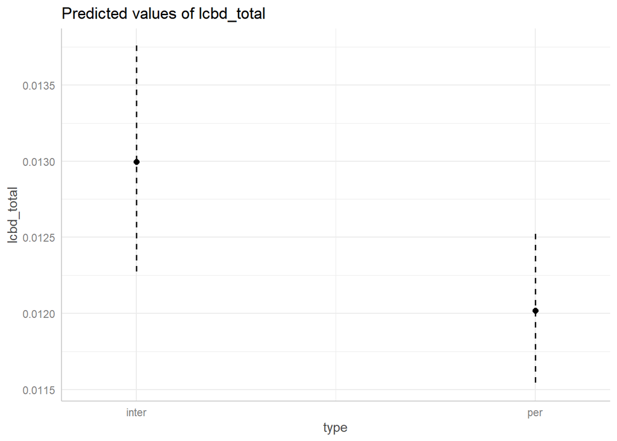

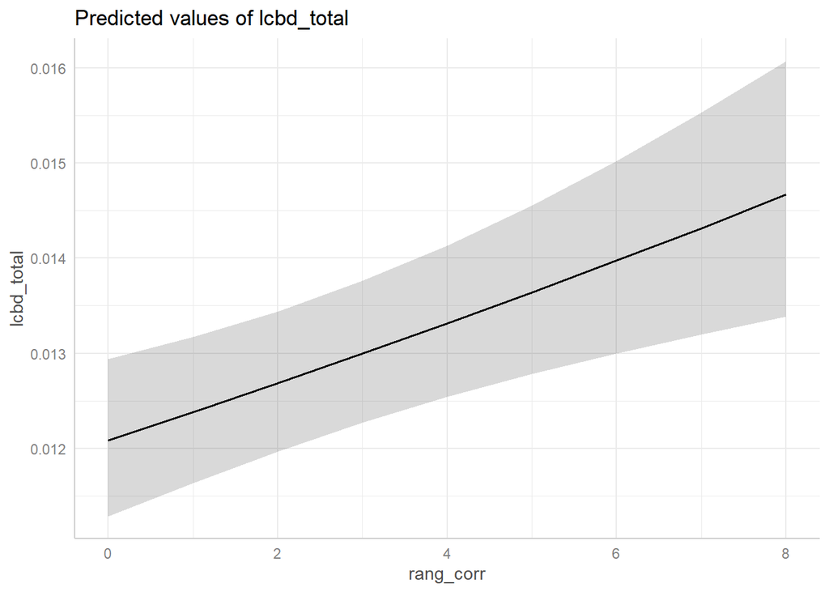

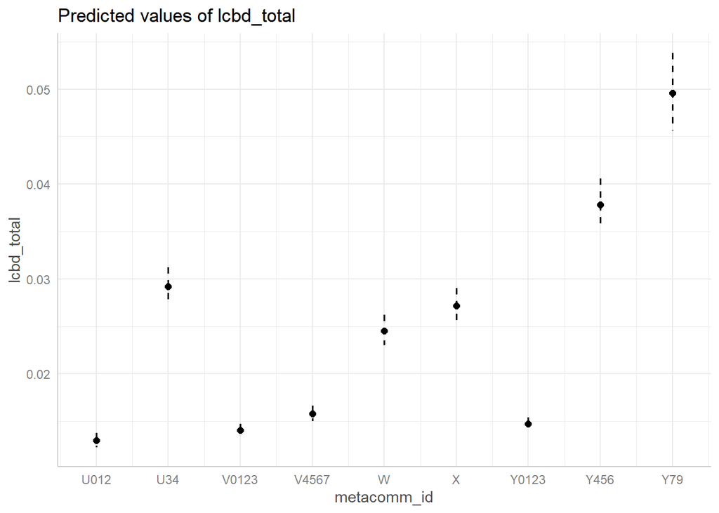

```r
ggpredict(model_gamma) %>% plot()
```

## 9 Autocorrelação espacial dos resíduos

Tudo parece explicar muito bem, com um ótimo ajuste. Vamos ver se há autocorrelação espacial nos resíduos do modelo Gamma.

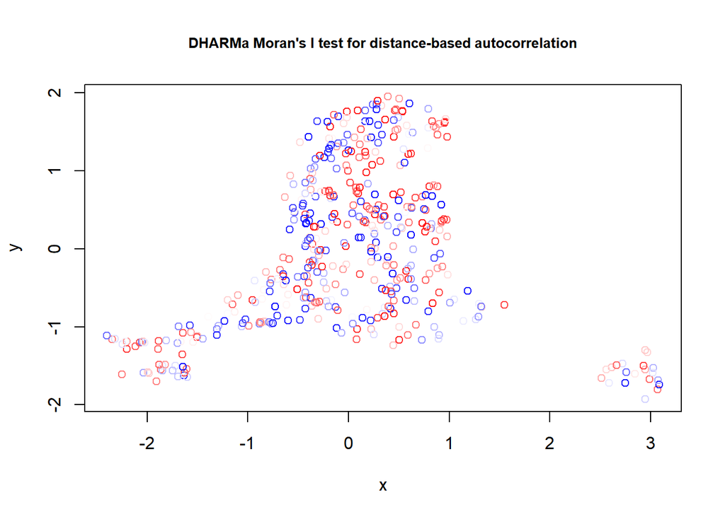

```
##
##  DHARMa Moran's I test for distance-based autocorrelation
##
## data:  resG
## observed = 0.0162459, expected = -0.0022321, sd = 0.0065285, p-value =
## 0.00465
## alternative hypothesis: Distance-based autocorrelation
```

```r
testSpatialAutocorrelation(resG, x = dados$longitude, y = dados$latitude)
```

O teste de autocorrelação identificou que há autocorrelação espacial. Vamos tentar adicionar as variáveis de latitude e longitude no modelo e ver o que acontece com os resíduos:

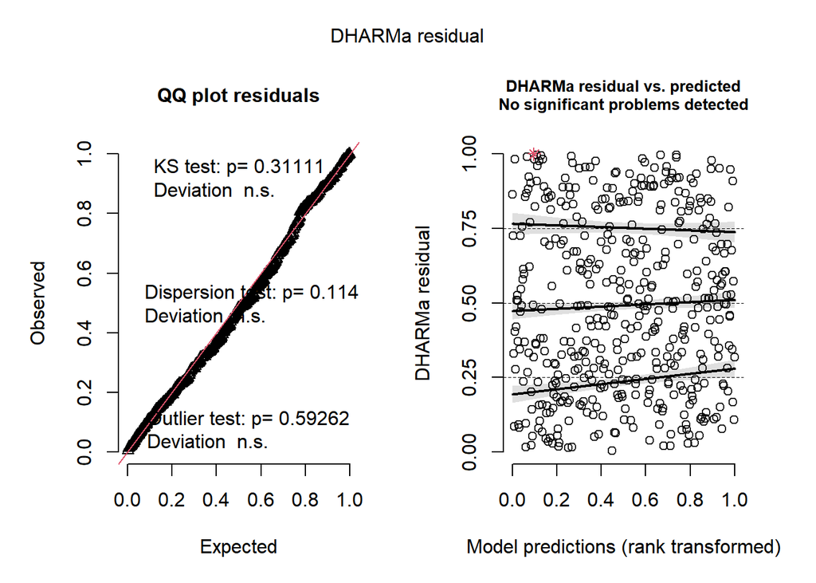

```r
model_gamma1 <- glmmTMB(
  lcbd_total ~ type + rang_corr + metacomm_id + latitude*longitude,
  data = dados,
  family = Gamma("log")
)


resG <- simulateResiduals(model_gamma1, n = 1000, plot = TRUE)
```

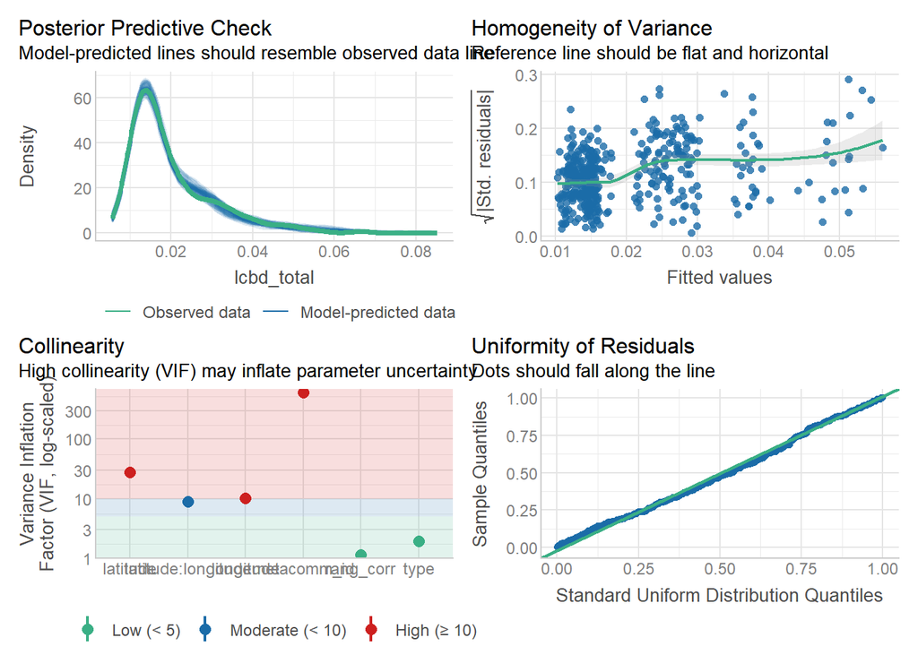

```r
check_model(model_gamma1)
```

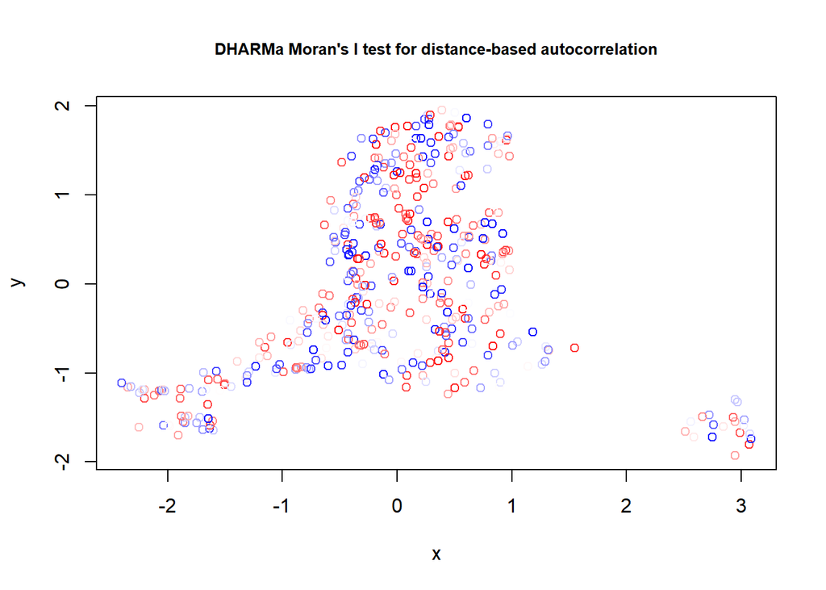

```
##
##  DHARMa Moran's I test for distance-based autocorrelation
##
## data:  resG
## observed = -5.5057e-05, expected = -2.2321e-03, sd = 6.5285e-03,
## p-value = 0.7388
## alternative hypothesis: Distance-based autocorrelation
```

```r
testSpatialAutocorrelation(resG, x = dados$longitude, y = dados$latitude)
```

```r
summary(model_gamma1)
```

```
##  Family: Gamma  ( log )
## Formula:
## lcbd_total ~ type + rang_corr + metacomm_id + latitude * longitude
## Data: dados
##
##       AIC       BIC    logLik -2*log(L)  df.resid
##   -3826.5   -3764.9    1928.2   -3856.5       434
##
##
## Dispersion estimate for Gamma family (sigma^2): 0.0333
##
## Conditional model:
##                    Estimate Std. Error z value Pr(>|z|)
## (Intercept)        -4.23426    0.07166  -59.09  < 2e-16 ***
## typeper            -0.04311    0.02381   -1.81 0.070239 .
## rang_corr           0.02156    0.00677    3.18 0.001453 **
## metacomm_idU34      0.66763    0.05012   13.32  < 2e-16 ***
## metacomm_idV0123   -0.04712    0.05412   -0.87 0.383922
## metacomm_idV4567   -0.04027    0.08767   -0.46 0.646013
## metacomm_idW        0.47225    0.07539    6.26 3.75e-10 ***
## metacomm_idX        0.48344    0.10434    4.63 3.60e-06 ***
## metacomm_idY0123   -0.09000    0.11222   -0.80 0.422569
## metacomm_idY456     0.76562    0.12448    6.15 7.73e-10 ***
## metacomm_idY79      0.75036    0.21301    3.52 0.000427 ***
## latitude           -0.10650    0.04546   -2.34 0.019137 *
## longitude          -0.04338    0.02741   -1.58 0.113514
## latitude:longitude -0.08081    0.01935   -4.18 2.95e-05 ***
## ---
## Signif. codes:  0 '***' 0.001 '**' 0.01 '*' 0.05 '.' 0.1 ' ' 1
```